```python
import pandas as pd
import geopandas as gpd
import matplotlib.pyplot as plt
import plotly.express as px
import plotly.offline as pyo
import plotly.graph_objs as go

from src.pdfs_to_text import pdfs_downloader
from src.textual_features import agent_extraction

from llama_index.core import (
    VectorStoreIndex,
    SimpleDirectoryReader,
    PromptTemplate,
    StorageContext,
    load_index_from_storage,
    Settings
)

pyo.init_notebook_mode(connected=True)
```

# Digitalization of building plans in Bavaria

## MS1: Develop scraping tool for Bauleitpläne in Bavaria

For this project, we worked scraping the GeoBayern Services API. We downloaded metadata: information about the Stadt, year of the building plan, and the links. We used the column 'URL zur Legende' to download the building plans. The criteria for this was that the columns 'URL zur Raster' contained only the raster image in some cases, and in others the same PDF as the column we used.

Each PDF was downloaded and split into images to parse the content more easily. Therefore, we will be working with two datasets:

- `metadata`: each row is a BP. Information of the year, Gemeinde, the links.
- `bp_text`: each row is a *page* of a BP. Text content of that page.

```python
metadata = pd.read_csv('./data/proc/building_plans/metadata/building_plans_metadata.csv')
bp_text = pd.read_json('./data/proc/building_plans/text/bp_text.json')
```

Additionally, we downloaded a dataframe of Bayern Gemeinde geographical information. This dataframe is not official, but it is useful to get a list of the Gemeinden in Bavaria to compare the coverage in the geoservices API.

```python
geo_data = gpd.read_file('./data/final/bavaria_geodata.geojson',
                   sep=';')

#Processing the format of the names.

geo_data['gem_name_short'] = geo_data['gem_name_short'].apply(lambda x: ', '.join(x))
```

We can check how many Gemeinden have uploaded building plans to the open data portal.

```python
metadata['Stadt/Gemeinde'].nunique()
```

```
422
```

But, what percentage of all of Bavaria's Gemeinden have uploaded them?

```python
metadata['Stadt/Gemeinde'].nunique()/geo_data['gem_name_short'].nunique()
```

```
0.19375573921028466
```

Only 19% of the Stadts in Bavaria uploaded their building plans. It's important to note that we are comparing two different sources, so both lists are not entirely comparable. To do this comparison we need a reliable source of Geimeinden in Bavaria, ideally from the same source of the scraping.

## MS2: Enhance current OCR-tool

The second goal was to improve the OCR tool. We did so by using a different parser: instead of Tika, the package `easyocr`. To use it, we also transformed the pdfs into jpgs where each image is a page of the PDF.

Therefore, to get the count of parsed building plans we need to do some processing. We will create the column `id` in the `bp_text` to uniquely identify each building plan instead of pages.

```python
bp_text['id'] = bp_text['filename'].str.extract(r'(\d+)_\d+\.jpg')
bp_text['id'] = pd.to_numeric(bp_text['id'], errors='coerce')
```

Now, we make a list without duplicates to get the unique ID of the PDFs.

```python
bp=bp_text['id'].drop_duplicates()

bp.head()
```

```
0    58731
1    86609
2    50989
3    86392
4    56758
Name: id, dtype: int64
```

Now, we will filter the metadata to the interval of years of PDFs we downloaded (2000-2023).

```python
metadata = pdfs_downloader.filtering_useful_data(date_column = 'Datum des Inkrafttretens',
                          start_date = '2000-01-01',
                          end_date = '2024-01-01',
                          data = metadata)
```

```python
bp_metadata = len(metadata)
print('Number of total building plans: ',bp_metadata)
```

```
Number of total building plans:  6622
```

For this interval of time, there were 6.622 registered building plans.

Now, we will join it to the `metadata` base and drop duplicates to filter the building plans that were parsed.

```python
data = metadata.merge(bp_text['id']).drop_duplicates()
```

We can check how many BP were downloaded and parsed:

```python
len(data)
```

```
4559
```

```python
len(data)/len(metadata)
```

```
0.6884627000906071
```

We covered 68% of these building plans. In the file `error_links.csv` you can check which files returned error when they were tried to download.

## Time analysis

```python
# Create new columns for year and month
data['year'] = data['Datum des Inkrafttretens'].dt.year
data['month'] = data['Datum des Inkrafttretens'].dt.month

# Group by year and month, then count the values
result = data.groupby(['year']).size().reset_index(name='count')
```

```python
result
```

|  | year | count |
| --- | --- | --- |
| 0 | 2000 | 353 |
| 1 | 2001 | 285 |
| 2 | 2002 | 191 |
| 3 | 2003 | 207 |
| 4 | 2004 | 232 |
| 5 | 2005 | 219 |
| 6 | 2006 | 254 |
| 7 | 2007 | 176 |
| 8 | 2008 | 168 |
| 9 | 2009 | 174 |
| 10 | 2010 | 169 |
| 11 | 2011 | 187 |
| 12 | 2012 | 176 |
| 13 | 2013 | 161 |
| 14 | 2014 | 167 |
| 15 | 2015 | 196 |
| 16 | 2016 | 167 |
| 17 | 2017 | 180 |
| 18 | 2018 | 170 |
| 19 | 2019 | 203 |
| 20 | 2020 | 179 |
| 21 | 2021 | 138 |
| 22 | 2022 | 115 |
| 23 | 2023 | 92 |

How did the BP distribution appear through the years?

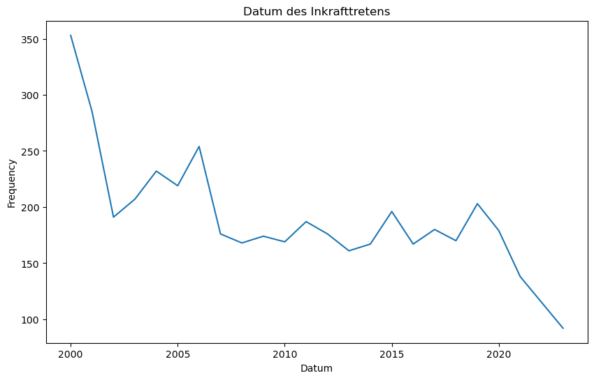

```python
plt.figure(figsize=(10, 6))  # Optional: Adjust the figure size
plt.plot(result['year'], result['count'])
plt.title('Datum des Inkrafttretens')
plt.xlabel('Datum')
plt.ylabel('Frequency')
plt.show()
```

The year with the highest ammount of building plans is 2000, with 353 plans. It is followed by 2001 with 285 plans and 254. The year with the least building plans registered was 2023.

## Gemeinden analysis

What about the distribution of building plans per Gemeinden?

```python
unique_stadt = metadata['Stadt/Gemeinde'].nunique()

print('Number of Gemeinden with building plans registered: ',unique_stadt)
```

```
Number of Gemeinden with building plans registered:  384
```

```python
stadt_counts = data['Stadt/Gemeinde'].value_counts().reset_index(name='count')

stadt_counts.describe()
```

|  | count |
| --- | --- |
| count | 291.000000 |
| mean | 15.666667 |
| std | 27.627614 |
| min | 1.000000 |
| 25% | 3.000000 |
| 50% | 7.000000 |
| 75% | 14.500000 |
| max | 225.000000 |

- 291 Gemeinden had their PDF downloaded and parsed.
- The mean count of building plans per Stadt is of 15 plans.
- The maximum ammount of building plans that the stadts have is of 225.

This arises the issue that there are a few Gemeinden that register many building plans, while there are others that only show a few. For example, if we look at how many Stadt concentrate the 80% of building plans.

```python
stadt_counts['accumulated_percentage'] = stadt_counts['count'].cumsum() / stadt_counts['count'].sum() * 100
stadt_counts[stadt_counts['accumulated_percentage'] < 80]
```

|  | Stadt/Gemeinde | count | accumulated_percentage |
| --- | --- | --- | --- |
| 0 | Hauzenberg | 225 | 4.935293 |
| 1 | Fürstenzell | 216 | 9.673174 |
| 2 | Regen | 144 | 12.831761 |
| 3 | Pocking | 144 | 15.990349 |
| 4 | Deggendorf | 110 | 18.403159 |
| ... | ... | ... | ... |
| 85 | Markt Nordheim | 13 | 78.898881 |
| 86 | Miltenberg | 13 | 79.184032 |
| 87 | Elfershausen | 12 | 79.447247 |
| 88 | Eschau | 12 | 79.710463 |
| 89 | Unterpleichfeld | 12 | 79.973678 |

90 rows × 3 columns

The information is sparse: 30% of the Gemeinden accumulate over 80% of the building plans available. What are the stadts that reported most building plans?

```python
top_stadt = stadt_counts.head(20)
```

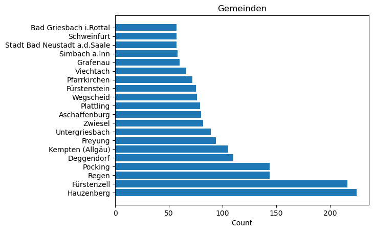

```python
# Plotting
fig, ax = plt.subplots()

ax.barh(top_stadt['Stadt/Gemeinde'], top_stadt['count'])
plt.title('Gemeinden')
plt.xlabel('Count')
plt.ylabel('')
plt.show()
```

We can also plot this information in a map. However, note that **we do not have the information from the original building plans source**, we will join it with the secondary source.

```python
stadt_counts_geo = stadt_counts.merge(geo_data[['gem_name_short', 'geometry']], left_on = 'Stadt/Gemeinde',
                                      right_on = 'gem_name_short')

stadt_counts_geo = stadt_counts_geo.set_geometry("geometry").set_index("Stadt/Gemeinde")

len(stadt_counts_geo)
```

```
242
```

Note that we only have 242 Gemeinden instead of the 291 that were parsed. We lost 49 Gemeinden in this process. However, this allows us to display the information in a plot.

```python
fig = px.choropleth_mapbox(stadt_counts_geo,
                           geojson=stadt_counts_geo.geometry,
                           locations=stadt_counts_geo.index,
                           color='count',
                           color_continuous_scale="Viridis",
                           mapbox_style="carto-positron",
                           zoom=6,
                           center = {"lat": 48.777500, "lon": 11.431111},
                           opacity=0.5,
                           labels={'count':'Number of BP'}
                          )

fig.update_layout(margin={"r":0,"t":0,"l":0,"b":0})

pyo.iplot(fig)
```

[interactive chart not shown]

## MS3: Investigate if there is a specialised LLM for planning text and proof of concept and fact check output

Lastly, we investigated a LLM agent that can be used to extract the information from the building plans. We used the LlamaIndex GPT access to build a prompt and ask individually each page for the information.

First, we select an example of one page of a building plan that contains references to the items we want to extract info from and save it in the folder text_bplans.

```python
example_archive = bp_text[bp_text['filename'] == '8784_0.jpg']
content = example_archive['content']
content = content.astype(str)

content.to_csv('./data/final/bplan/text_bplans/8784_0.txt', header=None, index=None, sep='\t', mode='w')
```

Next, we need to load the LLM model and embedding from the API. To do so, you just have to set your keys and endpoint in the function `load_models` from the module `agent_extraction`.

```python
OPENAI_API_KEY =  "your_openai_key"
OPENAI_ENDPOINT = "your_openai_endpoint"

agent_extraction.load_models(AZURE_OPENAI_ENDPOINT = OPENAI_ENDPOINT,
                             AZURE_OPENAI_API_KEY = OPENAI_API_KEY)
```

Next, we load the text in the folder where the example building plan is stored.

```python
index = agent_extraction.load_data('./data/final/bplan/text_bplans')
```

```
INFO:httpx:HTTP Request: POST https://lmu-soda-openai-fr-instance.openai.azure.com//openai/deployments/text-embedding-ada-002/embeddings?api-version=2023-07-01-preview "HTTP/1.1 200 OK"
HTTP Request: POST https://lmu-soda-openai-fr-instance.openai.azure.com//openai/deployments/text-embedding-ada-002/embeddings?api-version=2023-07-01-preview "HTTP/1.1 200 OK"
HTTP Request: POST https://lmu-soda-openai-fr-instance.openai.azure.com//openai/deployments/text-embedding-ada-002/embeddings?api-version=2023-07-01-preview "HTTP/1.1 200 OK"
```

Following this we define the template prompt for the query. In the prompt we provide information and context regarding the text and how the information should appear.

```python
# Define a custom prompt
template = (
    "Im folgenden geht es um den Wert {keyword}.\n"
    "Extrahieren Sie den entsprechenden numerischen Wert aus dem Text.\n"
    "Der Output wird erwartet in folgender Form: {keyword_short}: Zahl Maßeinheit.\n"
    "Wenn der Wert nicht gefunden werden kann, antworte 'None'.\n"
    "---------------------\n"
    "Siehe die folgenden Beispiele:\n"
    "Input: 'wird für die gfz die höchstgrenze von 1,2 festgesetzt' = Output: 'gfz: 1,2'\n"
    "Input: 'setzt eine grund / geschossflächenzahl von 0,4 / 0,5 fest' = Output: 'gfz: 0,5'\n"
    "---------------------\n"
    "Hier ist der Text: {context_str}\n"
)

prompt_tmpl = PromptTemplate(template)
```

We then define the format of the prompt: the keywords it should look for and their short abbreviation.

```python
partial_prompt_tmpl = prompt_tmpl.partial_format(keyword="Geschossflächenzahl",
                                                 keyword_short = "GFZ")
```

Then we use the query engine to extract info.

```python
query_engine = index.as_query_engine(
        text_qa_template=partial_prompt_tmpl,
        )

response = query_engine.query("Was ist die Geschoßflächenzahl?")
```

```
INFO:httpx:HTTP Request: POST https://lmu-soda-openai-fr-instance.openai.azure.com//openai/deployments/text-embedding-ada-002/embeddings?api-version=2023-07-01-preview "HTTP/1.1 200 OK"
HTTP Request: POST https://lmu-soda-openai-fr-instance.openai.azure.com//openai/deployments/text-embedding-ada-002/embeddings?api-version=2023-07-01-preview "HTTP/1.1 200 OK"
HTTP Request: POST https://lmu-soda-openai-fr-instance.openai.azure.com//openai/deployments/text-embedding-ada-002/embeddings?api-version=2023-07-01-preview "HTTP/1.1 200 OK"
INFO:httpx:HTTP Request: POST https://lmu-soda-openai-fr-instance.openai.azure.com//openai/deployments/gpt-35-turbo-1106/chat/completions?api-version=2023-07-01-preview "HTTP/1.1 200 OK"
HTTP Request: POST https://lmu-soda-openai-fr-instance.openai.azure.com//openai/deployments/gpt-35-turbo-1106/chat/completions?api-version=2023-07-01-preview "HTTP/1.1 200 OK"
```

And print the response.

```python
response.response
```

```
"Output: 'gfz: 1,2'"
```

This agent proves to be an exceptionally potent tool for extracting information from PDFs. Not only can we request specific details, such as the Geschoßflächenzahl, and receive accurate outputs, but we can also seek broader information related to structural use metrics.

```python
query_engine = index.as_query_engine()
response = query_engine.query("What are the measurements for each element of the structural use?")
print(response)
```

```
INFO:httpx:HTTP Request: POST https://lmu-soda-openai-fr-instance.openai.azure.com//openai/deployments/text-embedding-ada-002/embeddings?api-version=2023-07-01-preview "HTTP/1.1 200 OK"
HTTP Request: POST https://lmu-soda-openai-fr-instance.openai.azure.com//openai/deployments/text-embedding-ada-002/embeddings?api-version=2023-07-01-preview "HTTP/1.1 200 OK"
HTTP Request: POST https://lmu-soda-openai-fr-instance.openai.azure.com//openai/deployments/text-embedding-ada-002/embeddings?api-version=2023-07-01-preview "HTTP/1.1 200 OK"
INFO:httpx:HTTP Request: POST https://lmu-soda-openai-fr-instance.openai.azure.com//openai/deployments/gpt-35-turbo-1106/chat/completions?api-version=2023-07-01-preview "HTTP/1.1 200 OK"
HTTP Request: POST https://lmu-soda-openai-fr-instance.openai.azure.com//openai/deployments/gpt-35-turbo-1106/chat/completions?api-version=2023-07-01-preview "HTTP/1.1 200 OK"
The measurements for each element of the structural use include the following:
- For the MI area: GRZ (floor area ratio) is up to 0.6, GFZ (site area ratio) is up to 1.2, and the maximum number of floors is determined by the building height.
- For the GE and GEA areas: GRZ is up to 0.8, GFZ is up to 2.4, and the maximum number of floors is determined by the building height, with exceptions for technically necessary subordinate building parts.
```

Hence, Azure OpenAI serves as a Language Model (LLM) that aligns with our objectives. Although it may not be a specialized agent, it demonstrates an ability to comprehend German building plans and effectively extract the pertinent information required for our project.